# mapa

# UBICACIÓN DE LOS CLIENTES

```python
data_clientes = pd.read_csv('clientes_xys.csv', index_col=0)
```

```python
data_clientes
```

|  | prov | lat | lng |
| --- | --- | --- | --- |
| cliente1 | zaragoza | 41.648823 | -0.889085 |
| cliente2 | oviedo | 43.361915 | -5.849389 |
| cliente3 | huesca | 42.131845 | -0.407806 |
| cliente4 | madrid | 40.416775 | -3.703790 |
| cliente5 | bilbao | 43.263013 | -2.934985 |

> **NOTA:** En los mapas físicos, las coordenadas están expresadas en grados minutos y segundos, por ejemplo Madrid sería 40°25′08″N 3°41′31″O

Para convertir a decimal:

$$40°25′08″ N = 40 + \frac{25}{60} + \frac{08}{3600} = 40.41888888888889\\$$$$3°41′31″ O = -(3 + \frac{41}{60} + \frac{31}{3600}) = -3.6919444444444447\\$$

> La longitud se multiplica por **negativo**, porque está a la **izquierda (oeste)** del punto 0,0.

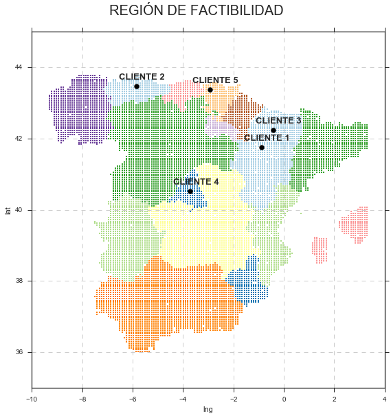

```python
# MAPA↔
```

[figure not shown]

```python
yi = data_clientes.lat.values
xi = data_clientes.lng.values
yxi = data_clientes[['lat', 'lng']]
```

## COSTES y PESOS

### COSTE ($c$)

Datos: Observatorio de Costes del Transporte de Mercancías por Carretera (Enero 2015), para VEHÍCULO ARTICULADO DE CARGA GENERAL [1](http://www.fomento.gob.es/NR/rdonlyres/75019EB9-D1D4-48DD-B58C-91FBD81E8E3B/129718/ObservatorioCostesMercanciasenero2015.pdf)

```python
c = (1.211 + 1.029) / 2↔
c
```

```
1.12
```

### PESO ($w_i$)

Suponemos que esta empresa ya maximiza beneficios dado los precios, es decir, la oferta igual a la demanda, siendo ésta última la previsión estimada como la media de los últimos 3 años.

$w_i$ = $\frac{1}{T}·\sum_{t=2012}^{2015}(ventas_{it})$

T = Nº de observaciones entre 2012 y 2015

```python
ventas.head()
```

|  | cliente1 | cliente2 | cliente3 | cliente4 | cliente5 |
| --- | --- | --- | --- | --- | --- |
| 1995-01-08 | 1057.125631 | 981.139096 | 993.012834 | 921.485244 | 1054.929112 |
| 1995-01-15 | 1058.038797 | 965.762513 | 991.368924 | 925.506056 | 1061.149308 |
| 1995-01-22 | 1050.353065 | 965.344514 | 991.796473 | 926.670731 | 1051.103377 |
| 1995-01-29 | 1053.505761 | 968.235378 | 993.462416 | 916.929766 | 1051.009594 |
| 1995-02-05 | 1052.877501 | 970.913001 | 997.258392 | 930.976354 | 1056.968813 |

```python
ventas.loc['2012':].head()
```

|  | cliente1 | cliente2 | cliente3 | cliente4 | cliente5 |
| --- | --- | --- | --- | --- | --- |
| 2012-01-01 | 1077.325321 | 1111.050666 | 1165.249280 | 1251.370094 | 1386.671676 |
| 2012-01-08 | 1078.676390 | 1110.072113 | 1173.512154 | 1264.479155 | 1383.848146 |
| 2012-01-15 | 1078.811238 | 1119.408951 | 1176.267080 | 1251.089708 | 1387.171679 |
| 2012-01-22 | 1082.287853 | 1115.102705 | 1161.736463 | 1256.147852 | 1375.243082 |
| 2012-01-29 | 1085.285927 | 1113.971479 | 1169.211906 | 1254.006147 | 1388.195087 |

```python
wi = ventas.loc['2012':].mean()
```

```python
wi
```

```
cliente1    1088.188049
cliente2    1133.466342
cliente3    1188.070200
cliente4    1297.616717
cliente5    1429.070507
dtype: float64
```

```python
yxi['wi'] = wi
yxi
```

|  | lat | lng | wi |
| --- | --- | --- | --- |
| cliente1 | 41.648823 | -0.889085 | 1088.188049 |
| cliente2 | 43.361915 | -5.849389 | 1133.466342 |
| cliente3 | 42.131845 | -0.407806 | 1188.070200 |
| cliente4 | 40.416775 | -3.703790 | 1297.616717 |
| cliente5 | 43.263013 | -2.934985 | 1429.070507 |

# OPTIMIZACIÓN

```python
def func_obj1(yx0):
    'Función Obejtivo, xy0: Tupla, pares de coordenadas'
    di = lambda yxj: vincenty(yx0, yxj).km
    dist = yxi.apply(di, axis=1)
    return sum(dist * wi) * c
```

```python
rrange = (slice(spain_xys.lat.min(),spain_xys.lat.max(), 0.1),
          slice(spain_xys.lng.min(), spain_xys.lng.max(), 0.1))
```

```python
res1 = brute(func_obj1, rrange)
```

```python
res1
```

```
array([ 42.30156174,  -2.43768347])
```

## FUNCIONES AUXILIARES

```python
# FUNC. AUX.
d = spain_xys.copy()
def xys_ca(yx0):
    '''
    Convierte coordenadas en la CA a la que pertenece
    '''
    di = lambda yxj: np.sqrt(np.sum(np.power((np.array(yxj) - np.array(yx0)),2)))
    d['dist'] = d[['lat', 'lng']].apply(di, axis=1)
    res = d[d.dist == d.dist.min()]

    if res.dist.values > 0.1:
        ca = 'nf'
    else:
        ca = res.ca.values[0]

    return ca
```

```python
def impuesto_ca(yx0):↔

    if ca == 'nf':
        return np.inf
    else:
        res = ca_xys.loc[ca]
        return res.ti
```

```python
def r1(x):
    txt = '# RESULTADO:\n- __LAT:__ %s\n- __LONG:__ %s\n- __CCAA:__ %s: %s\n- __FUNCIÓN OBJETIVO:__ %s'
    return Markdown(txt % (*x, *ca_iso.loc[xys_ca(x)].values, func_obj1(x)))

def r2(x):
    txt = '# RESULTADO:\n- __LAT:__ %s\n- __LONG:__ %s\n- __CCAA:__ %s: %s\n- __FUNCIÓN OBJETIVO:__ %s'
    return Markdown(txt % (*x, *ca_iso.loc[xys_ca(x)].values, func_obj2(x)))
```

```python
r1(res1)
```

RESULTADO:

- **LAT:** 42.3015617419

- **LONG:** -2.43768347258

- **CCAA:** RI: La Rioja

- **FUNCIÓN OBJETIVO:** 1312334.97165

```python
opt = spain_xys.copy()
```

```python
opt.head()
```

|  | pais | ca | prov | lat | lng |
| --- | --- | --- | --- | --- | --- |
| 0 | ES | GA | Lugo | 42.778861 | -7.948673 |
| 1 | ES | GA | Lugo | 42.834314 | -7.948673 |
| 2 | ES | GA | Lugo | 42.889767 | -7.948673 |
| 3 | ES | GA | Lugo | 42.501594 | -7.858738 |
| 4 | ES | GA | Lugo | 42.557048 | -7.858738 |

# ALTERNATIVA:

```python
opt['fo1'] = opt[['lat', 'lng']].apply(func_obj1, axis=1)↔
```

```python
opt[opt.fo1 == opt.fo1.min()]
```

|  | pais | ca | prov | lat | lng | fo1 |
| --- | --- | --- | --- | --- | --- | --- |
| 7226 | ES | RI | LO | 42.335235 | -2.462668 | 1312459.026315 |

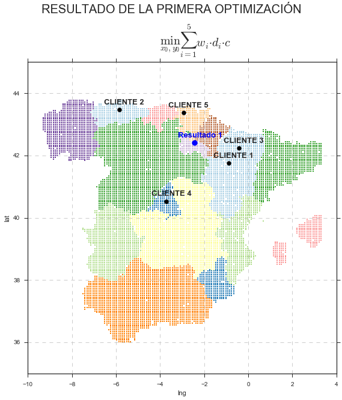

```python
# MAPA↔
```

[figure not shown]

# ANÁLISIS GRÁFICO

[figure not shown]

# INTRODUCCIÓN DE UNA RESTRICCIÓN ADICIONAL

Al problema anterior, le agregamos una variable adicional de tipo fiscal. Cada comunidad autónoma pasará a cobrar un impuesto por unidad vendida, el tipo impositivo dependerá de la comunidad autónoma, de forma que los costes para la empresa cambien y por tanto la elección óptima.

# PROBLEMA INICIAL + RESTRICCIÓN

## $\min_{x_0, y_0}{\sum_{i=1}^5{w_i · d_i·c(1 + t)}}$

**s.a.** $(x_0, y_0)$ $\in$ España

**DONDE:**

- $c$: Coste unitario (€/ud).
- $w_i$: Unidades demandadas de bienes (media de los últimos 3 años).
- $d_i$: Distancia al almacén (Km).
- $x_i$: Coordenada eje x (Longitud, decimal).
- $y_i$: Coordenada eje y (Latitud, decimal).
- **$t$: Impuesto por unidad vendida.**

**Variables de decisión (Coordenadas):** $x_0, y_0$

```python
ca_xys = pd.read_csv('ca_xys_ti.csv', index_col=0)
```

```python
ca_xys.head()
```

| name | codigo | nombre | name.1 | ti |
| --- | --- | --- | --- | --- |
| AN | ES-AN | Andalucía | AN | 0.582215 |
| AR | ES-AR | Aragón | AR | 0.805577 |
| AS | ES-AS | Asturias, Principado de | AS | 0.034853 |
| CN | ES-CN | Canarias | CN | 0.642867 |
| CB | ES-CB | Cantabria | CB | 0.990424 |

```python
spain_xys.head()
```

|  | pais | ca | prov | lat | lng |
| --- | --- | --- | --- | --- | --- |
| 0 | ES | GA | Lugo | 42.778861 | -7.948673 |
| 1 | ES | GA | Lugo | 42.834314 | -7.948673 |
| 2 | ES | GA | Lugo | 42.889767 | -7.948673 |
| 3 | ES | GA | Lugo | 42.501594 | -7.858738 |
| 4 | ES | GA | Lugo | 42.557048 | -7.858738 |

## FUNCIÓN OBJETIVO CON IMPUESTOS

```python
def func_obj2(yx0):
    'Función Obejtivo, xy0: Tupla, pares de coordenadas'
    di = lambda yxj: vincenty(yx0, yxj).km
    dist = yxi.apply(di, axis=1)
    res = sum(dist * wi) * c * (1 + impuesto_ca(yx0))
    return res
```

```python
rrange = (slice(spain_xys.lat.min(),spain_xys.lat.max(), 0.3),
          slice(spain_xys.lng.min(), spain_xys.lng.max(), 0.3))
```

```python
resbrute = brute(func_obj2, rrange, full_output=0, finish=fmin)
```

```python
resbrute
```

```
array([ 41.17071557,  -3.5140109 ])
```

```python
res2 = resbrute
```

```python
r2(res2)
```

RESULTADO:

- **LAT:** 41.1707155712

- **LONG:** -3.51401089789

- **CCAA:** MD: Madrid, Comunidad de

- **FUNCIÓN OBJETIVO:** 1562079.96239

```python
opt_copy = pd.read_csv('tabla_fos.csv')
```

```python
opt_copy.head()
```

|  | pais | ca | prov | lat | lng | fo1 | fo2 |
| --- | --- | --- | --- | --- | --- | --- | --- |
| 0 | ES | GA | Lugo | 42.778861 | -7.948673 | 3088986.707490 | 4333999.917642 |
| 1 | ES | GA | Lugo | 42.834314 | -7.948673 | 3091858.335598 | 4338028.952780 |
| 2 | ES | GA | Lugo | 42.889767 | -7.948673 | 3095347.215023 | 4342924.021801 |
| 3 | ES | GA | Lugo | 42.501594 | -7.858738 | 3036151.807412 | 4259869.960388 |
| 4 | ES | GA | Lugo | 42.557048 | -7.858738 | 3036002.350479 | 4259660.264977 |

```python
resultados = pd.read_csv('resultados.csv', index_col=0)
resultados
```

|  | lat | lng | fun_obj | ccaa |
| --- | --- | --- | --- | --- |
| res1 | 42.301562 | -2.437683 | 1312334.97165 | RI |
| res2 | 41.170716 | -3.514011 | 1562079.96239 | MD |

```python
resultados = pd.read_csv('resultados.csv', index_col=0)
resultados
```

|  | lat | lng | fun_obj | ccaa |
| --- | --- | --- | --- | --- |
| res1 | 42.301562 | -2.437683 | 1312334.971653 | RI |
| res2 | 41.170716 | -3.514011 | 1562079.962386 | MD |

```python
resultados.ix[0,2] = func_obj1(res1)
resultados.ix[1,2] = func_obj2(res2)

resultados
```

|  | lat | lng | fun_obj | ccaa |
| --- | --- | --- | --- | --- |
| res1 | 42.301562 | -2.437683 | 1312334.971653 | RI |
| res2 | 41.170716 | -3.514011 | 1562079.962386 | MD |

```python
res2 = resultados.loc[['res2'],['lat', 'lng']].values[0]
res2
```

```
array([ 41.17071557,  -3.5140109 ])
```

```python
opt.head()
```

|  | pais | ca | prov | lat | lng | fo1 | fo2 |
| --- | --- | --- | --- | --- | --- | --- | --- |
| 0 | ES | GA | Lugo | 42.778861 | -7.948673 | 3088986.707490 | 4333999.917642 |
| 1 | ES | GA | Lugo | 42.834314 | -7.948673 | 3091858.335598 | 4338028.952780 |
| 2 | ES | GA | Lugo | 42.889767 | -7.948673 | 3095347.215023 | 4342924.021801 |
| 3 | ES | GA | Lugo | 42.501594 | -7.858738 | 3036151.807412 | 4259869.960388 |
| 4 | ES | GA | Lugo | 42.557048 | -7.858738 | 3036002.350479 | 4259660.264977 |

```python
opt[opt.fo2 <= opt.fo2.min()]
```

|  | pais | ca | prov | lat | lng | fo1 | fo2 |
| --- | --- | --- | --- | --- | --- | --- | --- |
| 4314 | ES | MD | M | 41.115262 | -3.541882 | 1561639.350537 | 1578574.800196 |

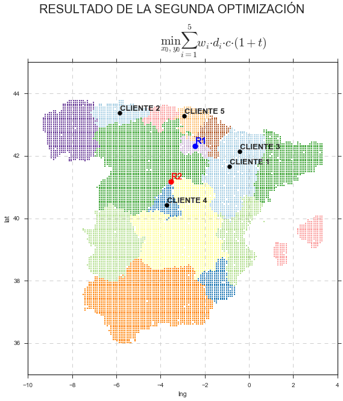

```python
# MAPA↔
```

[figure not shown]

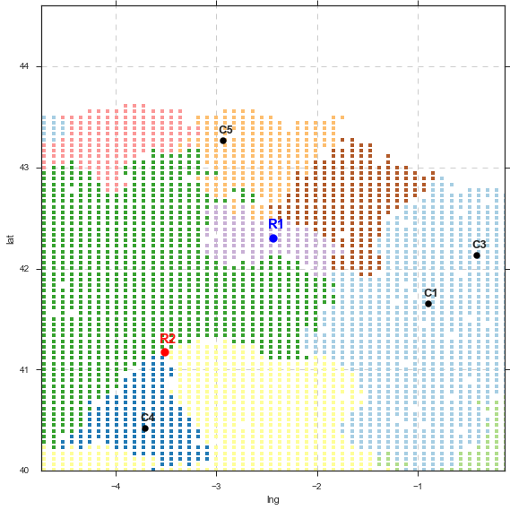

```python
# MAPA↔
```

[figure not shown]

```python
res1
```

```
array([ 42.30156174,  -2.43768347])
```

```python
resultados = {'res1': list(res1)+[func_obj1(res1), xys_ca(res1)],
              'res2': list(res2)+[func_obj2(res2), xys_ca(res2)]}
```

```python
resultados
```

```
{'res1': [42.301561741851827, -2.4376834725768637, 4686910.6130447527, 'RI'],
 'res2': [41.170715571194982, -3.5140108978924922, 5578857.0085271019, 'MD']}
```

```python
pd_res = pd.DataFrame.from_dict(resultados).T
pd_res.columns = ['lat', 'lng', 'fun_obj', 'ccaa']
#pd_res.to_csv('resultados.csv')
Markdown('# RESÚMEN\n' + pd_res.to_html())
```

RESÚMEN

|  | lat | lng | fun_obj | ccaa |
| --- | --- | --- | --- | --- |
| res1 | 42.3016 | -2.43768 | 4.68691e+06 | RI |
| res2 | 41.1707 | -3.51401 | 5.57886e+06 | MD |

# ANÁLISIS GRÁFICO

[figure not shown]

```python
ca_xys.head()
```

| name | codigo | nombre | name.1 | ti |
| --- | --- | --- | --- | --- |
| AN | ES-AN | Andalucía | AN | 0.582215 |
| AR | ES-AR | Aragón | AR | 0.805577 |
| AS | ES-AS | Asturias, Principado de | AS | 0.034853 |
| CN | ES-CN | Canarias | CN | 0.642867 |
| CB | ES-CB | Cantabria | CB | 0.990424 |

# MULTICRITERIO

## MINIMIZAR EL PAGO IMPOSITIVO

### Objetivo 1: $$\min_{x_0,y_0} Z_1 = \sum_{i=1}^5{w_i·t(x,y)}$$

## MINIMIZAR LOS COSTES DE TRASNSPORTE

### Objetivo 2: $$\min_{x_0, y_0}{Z_2 = \sum_{i=1}^5{w_i · d_i(x,y) · c}}$$

# Programación por metas MINIMAX o Tchebychev

## $\min\{\max{D}\}$

sa:

$d_i = \sqrt{(x_i - x_0)^2 + (y_i - y_0)^2}$

**DONDE:**

- $c$: Coste unitario (€/ud).
- $w_i$: Unidades demandadas de bienes (media de los últimos 3 años).
- $d_i$: Distancia al almacén (Km).
- $x_i$: Coordenada eje x (Longitud, decimal).
- $y_i$: Coordenada eje y (Latitud, decimal).
- **$t_j$: Impuesto por unidad vendida.** j={1-16}

**Variables de decisión (Coordenadas):** $x_0, y_0$

```python
p1 = lambda yx: (impuesto_ca(yx) - 0.2) / 0.2
p2 = lambda yx: (func_obj1(yx) - 2000000) / 2000000

def fobj3(yx):
    return max(p1(yx),p2(yx))
```

```python
res3 = fmin(fobj3, res1)
```

```
Optimization terminated successfully.
         Current function value: 1.348887
         Iterations: 72
         Function evaluations: 139
```

```python
res3
```

```
array([ 42.47386784,  -2.53406359])
```

```python
p1(_), p2(_)
```

```
(0.63608263254145392, 1.3488872033786961)
```

```python
def res_3(yx):
    ca = xys_ca(yx)
    ti = impuesto_ca(yx)
    fo = func_obj1(yx) + sum(wi * ti)
    txt = '# RESULTADO\n- __LAT:__ %s\n- __LONG:__ %s\n- __CCAA:__ %s\n- __ti:__ %s\n- __FUNC. OBJ.:__ %s'
    return Markdown(txt % (*yx, ca, ti, fo))
```

```python
res_3(res3)
```

RESULTADO

- **LAT:** 42.4738678398

- **LONG:** -2.53406358903

- **ti:** 0.327216526508

- **FUNC. OBJ.:** 4699782.34212

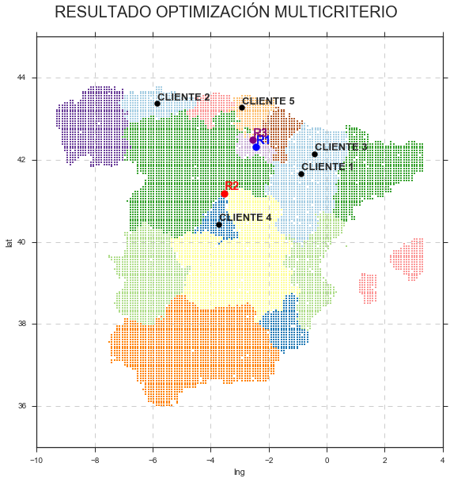

```python
# MAPA↔
```

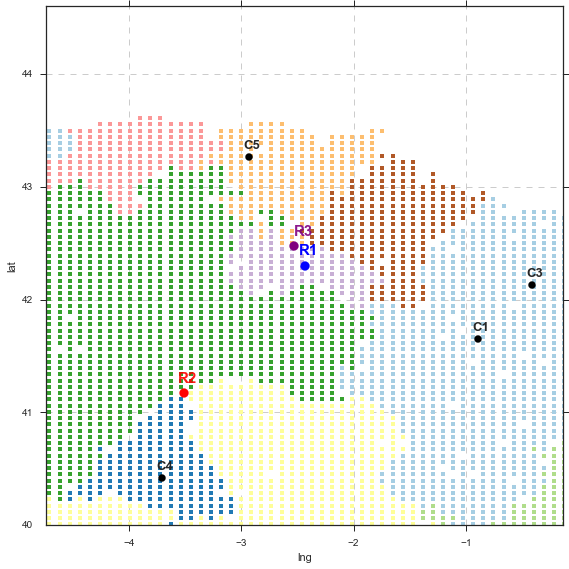

```python
# MAPA↔
```

[figure not shown]

```python
IFrame("https://www.google.com/maps/d/u/0/embed?mid=zTtXepJtMlLc.k6VXMPFTI7DI", width=940, height=580)↔
```

[interactive chart not shown]

```python
di1 = lambda yx: vincenty(yx, res1).km
di2 = lambda yx: vincenty(yx, res2).km

data_clientes['dist1'] = data_clientes[['lat', 'lng']].apply(di1, axis=1)
data_clientes['dist2'] = data_clientes[['lat', 'lng']].apply(di2, axis=1)
```

```python
data_clientes
```

|  | prov | lat | lng | dist1 | dist2 |
| --- | --- | --- | --- | --- | --- |
| cliente1 | zaragoza | 41.648823 | -0.889085 | 147.410125 | 225.796998 |
| cliente2 | oviedo | 43.361915 | -5.849389 | 302.771967 | 310.400117 |
| cliente3 | huesca | 42.131845 | -0.407806 | 168.657816 | 279.884499 |
| cliente4 | madrid | 40.416775 | -3.703790 | 234.601556 | 85.243187 |
| cliente5 | bilbao | 43.263013 | -2.934985 | 114.295030 | 237.271861 |

```python
mapquest_api = open('/Users/mmngreco/Documents/mq_api.txt').read()
gmaps_api = open('/Users/mmngreco/Documents/googlemaps_api.txt').read()
geocoder_api = open('/Users/mmngreco/Documents/geocoder_api.txt').read()
mbox_api = open('/Users/mmngreco/Documents/mbox_api.txt').read()
```

# LIMITACIONES Y AMPLIACIONES

## Errores de simplificación

- Se supone territorio es plano, no se tiene en cuenta la orografía. Se podría incluir la altitud en el análisis, para hacer el problema más real.

## Distancia y Orografía

- La distancia entre cada punto es la recta que las une, introducir la distancia entre provincias en carretera sería más realista para hallar el lugar óptimo, pero muy costoso.
- Se ha usado el algoritmo de Vicenty para calcular la distancia entre dos puntos.<sup>1</sup>(Español)<sup>2</sup>
1. https://en.wikipedia.org/wiki/Vincenty%27s_formulae
2. https://es.wikipedia.org/wiki/F%C3%B3rmulas_de_Vincenty

## Costes no reales.

- Los tipos impositivos han sido generados aleatoriamente a partir de una distribución uniforme 0,1. Bastaría sustituirlos por los reales para tener un resultado que se ajuste aún más a la realidad.

# ¡GRACIAS!

```python
from mpl_toolkits.mplot3d import Axes3D
```

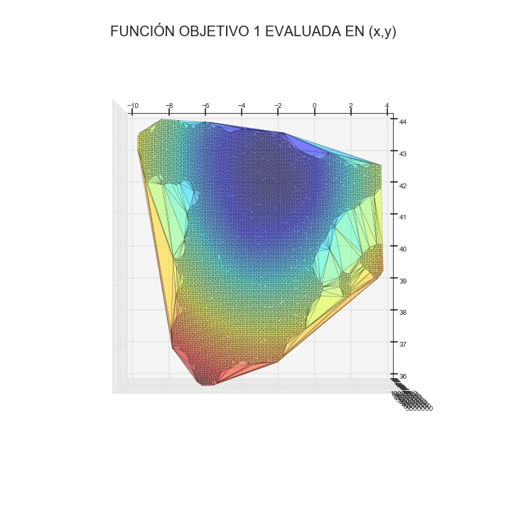

```python
# Creo otra figura y la almaceno en figura_3d
figura_3d = plt.figure(figsize=(10,10))

# Indicamos que vamos a representar en 3D
ax = figura_3d.gca(projection = '3d')

y = spain_xys.lat.values
x = spain_xys.lng.values
z = opt.fo1.values

ax.plot_trisurf(x,y,z, cmap=plt.cm.jet, alpha=0.5)

ax.view_init(90, -90)
plt.tight_layout()
plt.suptitle('FUNCIÓN OBJETIVO 1 EVALUADA EN (x,y)', fontsize=20, y=0.95)
plt.savefig('5.png', bbox_inches='tight')
```

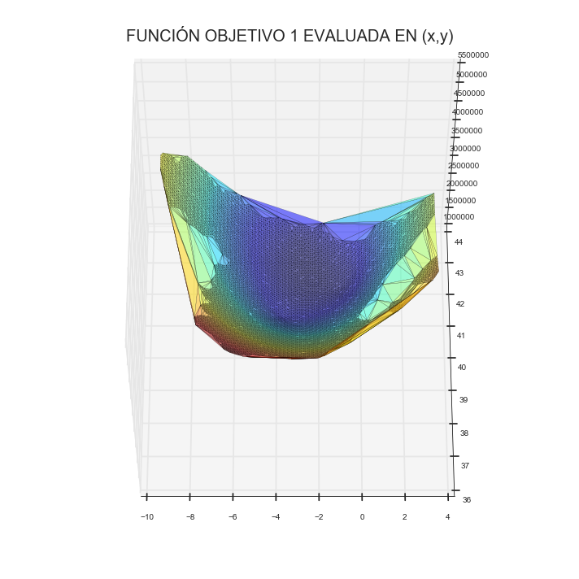

```python
# Creo otra figura y la almaceno en figura_3d
figura_3d = plt.figure(figsize=(10,10))

# Indicamos que vamos a representar en 3D
ax = figura_3d.gca(projection = '3d')

y = spain_xys.lat.values
x = spain_xys.lng.values
z = opt.fo1.values

ax.plot_trisurf(x,y,z, cmap=plt.cm.jet, alpha=0.5)

ax.view_init(60, -90)
plt.tight_layout()
plt.suptitle('FUNCIÓN OBJETIVO 1 EVALUADA EN (x,y)', fontsize=20, y=0.95)
plt.savefig('6.png', bbox_inches='tight')
```

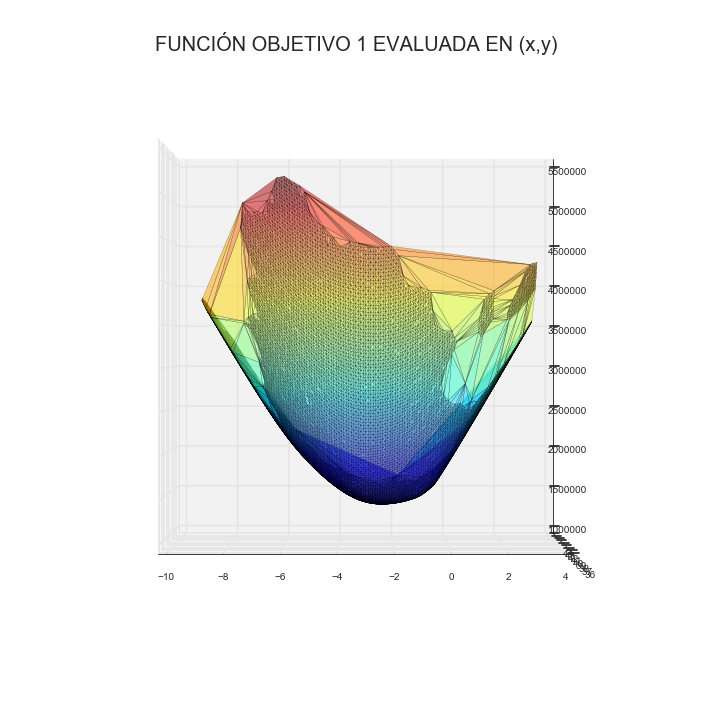

```python
# Creo otra figura y la almaceno en figura_3d
figura_3d = plt.figure(figsize=(10,10))

# Indicamos que vamos a representar en 3D
ax = figura_3d.gca(projection = '3d')

y = spain_xys.lat.values
x = spain_xys.lng.values
z = opt.fo1.values

ax.plot_trisurf(x,y,z, cmap=plt.cm.jet, alpha=0.5)

ax.view_init(0, -90)
plt.tight_layout()
plt.suptitle('FUNCIÓN OBJETIVO 1 EVALUADA EN (x,y)', fontsize=20, y=0.95)
plt.savefig('7.png', bbox_inches='tight')
```

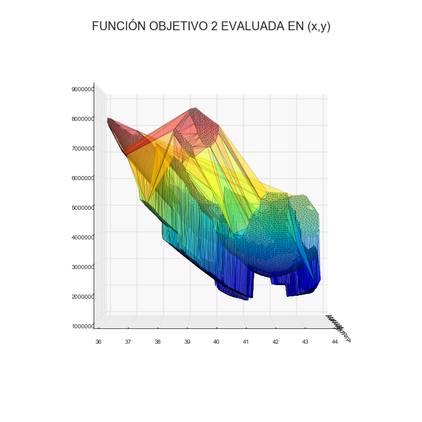

```python
# Creo otra figura y la almaceno en figura_3d
figura_3d = plt.figure(figsize=(10,10))
# Indicamos que vamos a representar en 3D
ax1 = figura_3d.gca(projection = '3d')

y = opt.lat.values
x = opt.lng.values
z = opt.fo2.values

ax1.plot_trisurf(x,y,z, cmap=plt.cm.jet, alpha=0.5)
ax1.view_init(0, 0)
plt.tight_layout()
plt.suptitle('FUNCIÓN OBJETIVO 2 EVALUADA EN (x,y)', fontsize=20, y=0.95)
plt.savefig('8.png', bbox_inches='tight')
```